# 08-iris_comparison

Katherine Goode

March 12, 2019

I am interested in how lime performs on other random forest models. This journal applies all of the input lime options to a random forest model fit to the iris data.

```r
# Load libraries
library(caret)
library(furrr)
library(future)
library(gretchenalbrecht)
library(lime)

# Source functions
source("../../code/helper_functions.R")
```

# Training and Testing Data

Iris is randomly split into training and testing datasets such that all of the species are represented in the testing data.

```r
# Set a seed
set.seed(20190311)

# Randomly select two cases from within each of the three species of irises
selected <- c(sample(1:50, 4), sample(51:100, 4), sample(101:150, 4))

# Determine the case numbers that were not selected
cases <- 1:150
not_selected <- cases[!(cases %in% selected)]

# Split up the features of the data into training and testing parts
iris_train <- iris[-selected, ]
iris_test <- iris[selected, ] %>% mutate(case = 1:n())
```

# Random Forest Model

A random forest model is fit to the iris data. The predictions from the model for the testing data are shown in the table below with the actual observed values. The model gets all of the predictions correct.

```r
# Random forest model run on the iris training data
iris_model <- train(x = iris_train %>% select(-Species),
                    y = iris_train %>% pull(Species),
                    method = 'rf')

# Predictions made using the random forest model on the testing data
iris_model_predict <- predict(iris_model, iris_test %>% select(-Species, - case))

# Matrix of observed and predicted values
iris_test_obs_pred <- data.frame(Observed = iris_test %>% pull(Species),
                                 Predicted = iris_model_predict)

# Print the table
knitr::kable(iris_test_obs_pred, align = 'c')
```

| Observed | Predicted |
| --- | --- |
| setosa | setosa |
| setosa | setosa |
| setosa | setosa |
| setosa | setosa |
| versicolor | versicolor |
| versicolor | versicolor |
| versicolor | versicolor |
| versicolor | versicolor |
| virginica | virginica |
| virginica | virginica |
| virginica | virginica |
| virginica | virginica |

# Apply LIME

```r
# Apply the run_lime function if the lime results file does not already exist
if(!file.exists("./data/iris_lime_inputs.rds")) {

  # Specify the input options to use with lime
  iris_lime_inputs <- list(bin_continuous = c(rep(TRUE, 15),
                                                  rep(FALSE, 2)),
                               quantile_bins = c(rep(TRUE, 5),
                                                 rep(FALSE, 5),
                                                 rep(TRUE, 7)),
                               nbins = c(rep(2:6, 3),
                                         rep(4, 2)),
                               use_density = c(rep(TRUE, 15), TRUE, FALSE),
                               bin_method = c(rep("quantile_bins", 5),
                                              rep("equally_spaced", 5),
                                              rep("tree", 5),
                                              rep("quantile_bins", 2)),
                               response = c(rep(NA, 10),
                                            rep("Species", 5),
                                            rep(NA, 2)))

  # Tell R to run the upcoming code in parallel
  plan(multiprocess)

  # Apply lime to the full training data with the specified input options
  iris_lime_explain <- future_pmap(.l = iris_lime_inputs,
             .f = run_lime, # run_lime is one of my helper functions
             features = names(iris %>% select(-Species)),
             train = iris_train,
             test = iris_test %>% select(-case, -Species),
             rfmodel = iris_model,
             label = "virginica",
             nfeatures = 3,
             seed = TRUE)

  # Separate the lime and explain function results from the full data
  iris_lime <- map(iris_lime_explain, function(list) list$lime)
  iris_explain <- map_df(iris_lime_explain, function(list) list$explain)

  # Name the items in the lime list
  names(iris_lime) <- map_chr(1:17, function(case)
      sprintf("case: bin_continuous = %s, quantile_bins = %s, nbins = %0.f, use_density = %s, bin_method = %s, response = %s",
              iris_lime_inputs$bin_continuous[case],
              iris_lime_inputs$quantile_bins[case],
              iris_lime_inputs$nbins[case],
              iris_lime_inputs$use_density[case],
              iris_lime_inputs$bin_method[case],
              iris_lime_inputs$response[case]))

  # Turn the lime input options into a dataframe before saving it
  iris_lime_inputs <- iris_lime_inputs %>%
    unlist() %>%
    matrix(ncol = length(iris_lime_inputs),
           dimnames = list(NULL, names(iris_lime_inputs))) %>%
    as.data.frame() %>%
    mutate(case = 1:length(iris_lime_inputs$quantile_bins)) %>%
    select(case, bin_continuous:response)

  # Save the lime objects
  saveRDS(iris_lime_inputs, "./data/iris_lime_inputs.rds")
  saveRDS(iris_lime, "./data/iris_lime.rds")
  saveRDS(iris_explain, "./data/iris_explain.rds")

} else {

  # Load in the lime objects
  iris_lime_inputs <- readRDS("./data/iris_lime_inputs.rds")
  iris_lime <- readRDS("./data/iris_lime.rds")
  iris_explain <- readRDS("./data/iris_explain.rds")

}
```

The explanations from LIME are joined with the testing data. Additionally, the random forest scores for the probability that a case is species virginica are added to the dataset. This is the only species that will be considered (for now at least).

```r
# Create the test_explain combined data if the file does not already exist
if(!file.exists("./data/iris_test_explain.rds")) {

  # Join the data and the explanations and edit and add additional variables
  iris_test_explain <- iris_test %>%
    mutate(case = as.character(case),
           rfscore = predict(iris_model, iris_test, type = "prob") %>% pull(virginica)) %>%
    full_join(iris_explain, by = "case") %>%
    mutate(case = factor(case),
           feature = factor(feature),
           nbins = factor(nbins)) %>%
    arrange(nbins) %>%
    mutate(nbins = as.numeric(as.character(nbins)),
           situation = ifelse(bin_continuous == TRUE & bin_method == "quantile_bins",
                              sprintf("%.0f quantile", nbins),
                              ifelse(bin_continuous == TRUE & bin_method == "equally_spaced",
                                     sprintf("%.0f equally spaced", nbins),
                                     ifelse(bin_continuous == TRUE & bin_method == "tree" &
                                              response == "Species",
                                            sprintf("%.0f tree", nbins),
                                            ifelse(bin_continuous == FALSE &
                                                   use_density == TRUE,
                                                   "kernel density",
                                                   "normal approximation")))) %>%
             fct_relevel("2 quantile", "3 quantile", "4 quantile",
                         "5 quantile", "6 quantile", "2 equally spaced",
                         "3 equally spaced", "4 equally spaced",
                         "5 equally spaced", "6 equally spaced",
                         "2 tree", "3 tree",
                         "4 tree", "5 tree",
                         "6 tree")) %>%
    mutate(bin_situation = ifelse(bin_method == "quantile_bins" &
                                  bin_continuous == TRUE,
                                  "quantile",
                                  ifelse(bin_method == "equally_spaced" &
                                         bin_continuous == TRUE,
                                         "equally spaced",
                                         ifelse(bin_method == "tree" &
                                                bin_continuous == TRUE &
                                                response == "Species",
                                                "tree",
                                                ifelse(bin_continuous == FALSE &
                                                       use_density == TRUE,
                                                       "kernel density",
                                                       "normal approximation"))))) %>%
    mutate(bin_situation = factor(bin_situation))

  # Save the combined test and explain data
  saveRDS(iris_test_explain, "./data/iris_test_explain.rds")

} else {

  # Load in the data
  iris_test_explain <- readRDS("./data/iris_test_explain.rds")

}
```

Summaries of the explanations are computed and saved in a dataset.

```r
# Create the lime comparison data if the file does not already exist
if(!file.exists("./data/iris_lime_comparisons.rds")) {

  # Create a data frame with the interesting information relating to the different
  # evaluations of lime and compute the difference and mean between the rf and rr
  # model predictions
  iris_lime_comparisons <- iris_test_explain %>%
    select(-data, -prediction) %>%
    group_by(case, bin_continuous, quantile_bins, nbins, use_density, bin_method) %>%
    slice(1) %>%
    ungroup() %>%
    mutate(diff = rfscore - model_prediction,
           mean = (rfscore + model_prediction) / 2)


  # Save the lime comparison data frame
  saveRDS(iris_lime_comparisons, "./data/iris_lime_comparisons.rds")

} else {

  # Load in the lime comparison data frame
  iris_lime_comparisons <- readRDS("./data/iris_lime_comparisons.rds")

}
```

# Visualizing LIME Results

All of the results in this section are in terms of the species virginica.

The MSEs and average $R^2$ values are computed for each of the estimation methods.

```r
# Summarizing lime results
iris_lime_results <- iris_lime_comparisons %>%
  group_by(situation, bin_situation, bin_continuous, quantile_bins, nbins, use_density,
           bin_method, response) %>%
  summarise(mse = (sum(diff^2)) / length(diff),
            ave_r2 = mean(model_r2)) %>%
  ungroup()
```

A plot of the MSEs is shown below.

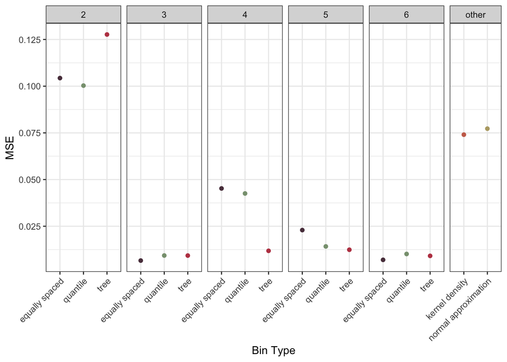

```r
# Plot of MSEs
iris_lime_results %>%
  mutate(bins = ifelse(nbins == 4 & bin_continuous == FALSE, "other", nbins)) %>%
  ggplot(aes(x = bin_situation, y = mse, color = bin_situation)) +
  geom_point() +
  facet_grid(~ bins, scales = "free_x", space = "free_x") +
  theme_bw() +
  theme(axis.text.x = element_text(angle = 45, hjust = 1),
        legend.position = "none") +
  labs(x = "Bin Type", y = "MSE", color = "") +
  scale_color_gretchenalbrecht(palette = "winged_spill", discrete = TRUE)
```

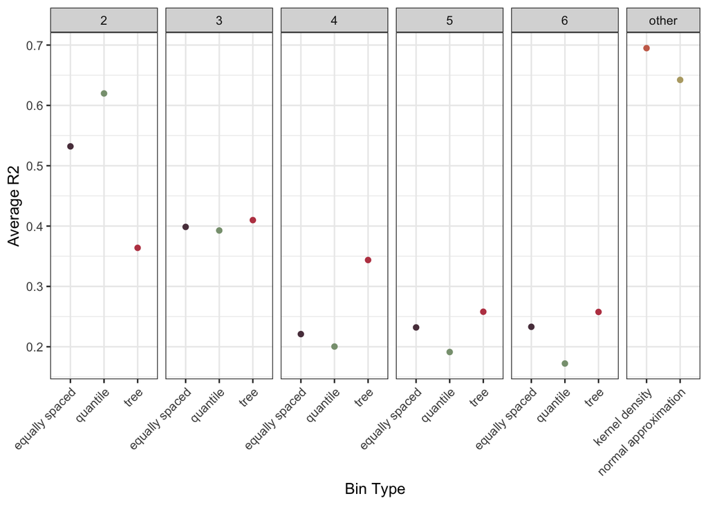

```r
# Plot of R^2s
iris_lime_results %>%
  mutate(bins = ifelse(nbins == 4 & bin_continuous == FALSE, "other", nbins)) %>%
  ggplot(aes(x = bin_situation, y = ave_r2, color = bin_situation)) +
  geom_point() +
  facet_grid( ~ bins, scales = "free_x", space = "free_x") +
  theme_bw() +
  theme(axis.text.x = element_text(angle = 45, hjust = 1),
        legend.position = "none") +
  labs(x = "Bin Type", y = "Average R2", color = "") +
  scale_color_gretchenalbrecht(palette = "winged_spill", discrete = TRUE)
```

The features chosen are sorted below.

```r
# Creates a dataset that creates columns of the chosen features by lime from first to third
iris_chosen_features <- iris_test_explain %>%
  filter(!(bin_situation %in% c("kernel density", "normal approximation"))) %>%
  filter(!is.na(rfscore)) %>%
  select(situation, bin_situation, nbins, case, feature, feature_weight) %>%
  mutate(feature_weight_abs = abs(feature_weight)) %>%
  arrange(situation, case, desc(feature_weight_abs)) %>%
  mutate(explainer = rep(c("first", "second", "third"), length(situation) / 3)) %>%
  select(-feature_weight, -feature_weight_abs) %>%
  spread(explainer, feature)
```

A plot of Fleiss’s kappa values is shown below.

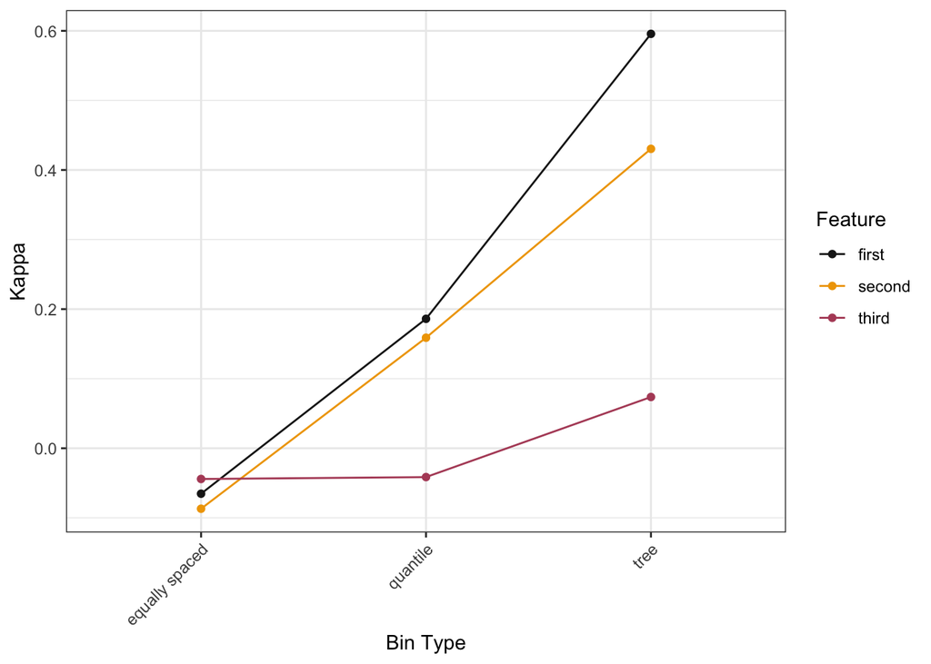

```r
# Computes and plots the values of kappa
iris_chosen_features %>%
  ungroup() %>%
  select(-situation) %>%
  gather(key = chosen, value = feature, first:third) %>%
  spread(nbins, feature) %>%
  select(-case) %>%
  rename(bins2 = "2", bins3 = "3", bins4 = "4", bins5 = "5", bins6 = "6") %>%
  group_by(bin_situation, chosen) %>%
  summarise(kappa =
              irr::kappam.fleiss(matrix(c(bins2, bins3, bins4, bins5, bins6),
                                        ncol = 5))$value) %>%
  arrange(chosen, bin_situation) %>%
  ggplot(aes(x = bin_situation, y = kappa, color = chosen, group = chosen)) +
  geom_point() +
  geom_line() +
  theme_bw() +
  theme(axis.text.x = element_text(angle = 45, hjust = 1)) +
  scale_color_gretchenalbrecht(palette = "pink_cloud", discrete = TRUE) +
  labs(x = "Bin Type", y = "Kappa", color = "Feature")
```

The following plots show the features chosen by each estimation method for all of the cases in the test dataset. The plots are created the by order the features are chosen (from first to third). I am not seeing the same patterns that I saw with the bullet data and `rtrees`. Heike pointed out that you really do not need a complex model to explain this situation. The iris data should be easy to predict. Maybe I could switch to using the problem points in the iris data for the test data and see how LIME performs with these.

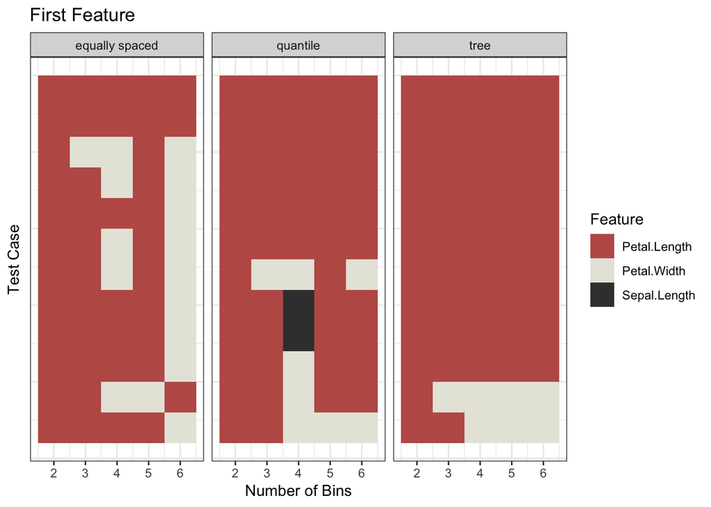

```r
# Plots the top feature for each case for each bin situation
iris_chosen_features %>%
  group_by(bin_situation, case) %>%
  mutate(nlevels = length(levels(factor(first)))) %>%
  ungroup() %>%
  arrange(bin_situation, desc(nlevels), case) %>%
  mutate(order = rep(rep(1:length(unique(case)), each = 5, 3))) %>%
  ggplot(aes(x = nbins, y = order, fill = first)) +
  geom_tile() +
  facet_grid( ~ bin_situation, scales = "free", space = "free_y") +
  theme_bw() +
  theme(axis.text.y = element_blank(),
        axis.ticks.y = element_blank()) +
  scale_fill_gretchenalbrecht(palette = "last_rays", discrete = TRUE) +
  labs(x = "Number of Bins", y = "Test Case", fill = "Feature", title = "First Feature")
```

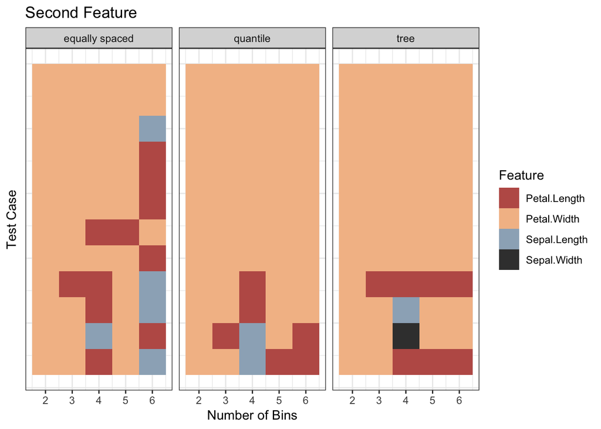

```r
# Plots the second feature for each case for each bin situation
iris_chosen_features %>%
  group_by(bin_situation, case) %>%
  mutate(nlevels = length(levels(factor(second)))) %>%
  ungroup() %>%
  arrange(bin_situation, desc(nlevels), case) %>%
  mutate(order = rep(rep(1:length(unique(case)), each = 5, 3))) %>%
  ggplot(aes(x = nbins, y = order, fill = second)) +
  geom_tile() +
  facet_grid( ~ bin_situation, scales = "free", space = "free_y") +
  theme_bw() +
  theme(axis.text.y = element_blank(),
        axis.ticks.y = element_blank()) +
  scale_fill_gretchenalbrecht(palette = "last_rays", discrete = TRUE) +
  labs(x = "Number of Bins", y = "Test Case", fill = "Feature", title = "Second Feature")
```

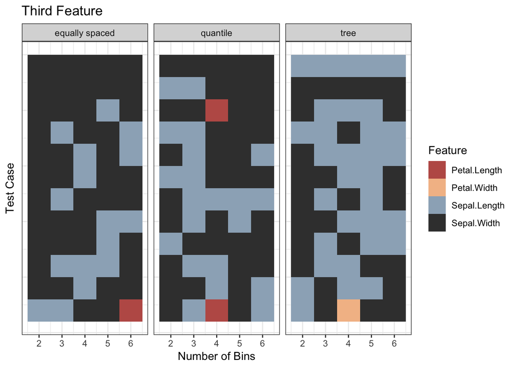

```r
# Plots the third feature for each case for each bin situation
iris_chosen_features %>%
  group_by(bin_situation, case) %>%
  mutate(nlevels = length(levels(factor(third)))) %>%
  ungroup() %>%
  arrange(bin_situation, desc(nlevels), case) %>%
  mutate(order = rep(rep(1:length(unique(case)), each = 5, 3))) %>%
  ggplot(aes(x = nbins, y = order, fill = third)) +
  geom_tile() +
  facet_grid( ~ bin_situation, scales = "free", space = "free_y") +
  theme_bw() +
  theme(axis.text.y = element_blank(),
        axis.ticks.y = element_blank()) +
  scale_fill_gretchenalbrecht(palette = "last_rays", discrete = TRUE) +
  labs(x = "Number of Bins", y = "Test Case", fill = "Feature", title = "Third Feature")
```